# Risk Factor Analysis

## Outcome Variable

**Outcome Variable:** pers_wasted624

## Predictor Variables

**Intervention Variable:** ever_sunderweight06

**Adjustment Set:**

- sex
- arm
- brthmon
- vagbrth
- single
- W_mage
- W_mhtcm
- W_mwtkg
- W_mbmi
- W_meducyrs
- W_feducyrs
- W_parity
- delta_brthmon
- delta_vagbrth
- delta_single
- delta_W_mage
- delta_W_mhtcm
- delta_W_mwtkg
- delta_W_mbmi
- delta_W_meducyrs
- delta_W_feducyrs
- delta_W_parity

## Stratifying Variables

The analysis was stratified on these variable(s):

- studyid
- country

## Data Summary

| studyid | country | ever_sunderweight06 | pers_wasted624 | n_cell | n | outcome_variable |
| --- | --- | --- | --- | --- | --- | --- |
| ki0047075b-MAL-ED | BANGLADESH | 0 | 0 | 210 | 240 | pers_wasted624 |
| ki0047075b-MAL-ED | BANGLADESH | 0 | 1 | 14 | 240 | pers_wasted624 |
| ki0047075b-MAL-ED | BANGLADESH | 1 | 0 | 13 | 240 | pers_wasted624 |
| ki0047075b-MAL-ED | BANGLADESH | 1 | 1 | 3 | 240 | pers_wasted624 |
| ki0047075b-MAL-ED | BRAZIL | 0 | 0 | 201 | 207 | pers_wasted624 |
| ki0047075b-MAL-ED | BRAZIL | 0 | 1 | 2 | 207 | pers_wasted624 |
| ki0047075b-MAL-ED | BRAZIL | 1 | 0 | 4 | 207 | pers_wasted624 |
| ki0047075b-MAL-ED | BRAZIL | 1 | 1 | 0 | 207 | pers_wasted624 |
| ki0047075b-MAL-ED | INDIA | 0 | 0 | 187 | 235 | pers_wasted624 |
| ki0047075b-MAL-ED | INDIA | 0 | 1 | 17 | 235 | pers_wasted624 |
| ki0047075b-MAL-ED | INDIA | 1 | 0 | 20 | 235 | pers_wasted624 |
| ki0047075b-MAL-ED | INDIA | 1 | 1 | 11 | 235 | pers_wasted624 |
| ki0047075b-MAL-ED | NEPAL | 0 | 0 | 221 | 235 | pers_wasted624 |
| ki0047075b-MAL-ED | NEPAL | 0 | 1 | 1 | 235 | pers_wasted624 |
| ki0047075b-MAL-ED | NEPAL | 1 | 0 | 12 | 235 | pers_wasted624 |
| ki0047075b-MAL-ED | NEPAL | 1 | 1 | 1 | 235 | pers_wasted624 |
| ki0047075b-MAL-ED | PERU | 0 | 0 | 259 | 270 | pers_wasted624 |
| ki0047075b-MAL-ED | PERU | 0 | 1 | 2 | 270 | pers_wasted624 |
| ki0047075b-MAL-ED | PERU | 1 | 0 | 8 | 270 | pers_wasted624 |
| ki0047075b-MAL-ED | PERU | 1 | 1 | 1 | 270 | pers_wasted624 |
| ki0047075b-MAL-ED | SOUTH AFRICA | 0 | 0 | 246 | 259 | pers_wasted624 |
| ki0047075b-MAL-ED | SOUTH AFRICA | 0 | 1 | 1 | 259 | pers_wasted624 |
| ki0047075b-MAL-ED | SOUTH AFRICA | 1 | 0 | 11 | 259 | pers_wasted624 |
| ki0047075b-MAL-ED | SOUTH AFRICA | 1 | 1 | 1 | 259 | pers_wasted624 |
| ki0047075b-MAL-ED | TANZANIA, UNITED REPUBLIC OF | 0 | 0 | 237 | 245 | pers_wasted624 |
| ki0047075b-MAL-ED | TANZANIA, UNITED REPUBLIC OF | 0 | 1 | 0 | 245 | pers_wasted624 |
| ki0047075b-MAL-ED | TANZANIA, UNITED REPUBLIC OF | 1 | 0 | 8 | 245 | pers_wasted624 |
| ki0047075b-MAL-ED | TANZANIA, UNITED REPUBLIC OF | 1 | 1 | 0 | 245 | pers_wasted624 |
| ki1000108-CMC-V-BCS-2002 | INDIA | 0 | 0 | 285 | 373 | pers_wasted624 |
| ki1000108-CMC-V-BCS-2002 | INDIA | 0 | 1 | 12 | 373 | pers_wasted624 |

[output cut: 90 more lines]

The following strata were considered:

- studyid: ki0047075b-MAL-ED, country: BANGLADESH
- studyid: ki0047075b-MAL-ED, country: BRAZIL
- studyid: ki0047075b-MAL-ED, country: INDIA
- studyid: ki0047075b-MAL-ED, country: NEPAL
- studyid: ki0047075b-MAL-ED, country: PERU
- studyid: ki0047075b-MAL-ED, country: SOUTH AFRICA
- studyid: ki0047075b-MAL-ED, country: TANZANIA, UNITED REPUBLIC OF
- studyid: ki1000108-CMC-V-BCS-2002, country: INDIA
- studyid: ki1000108-IRC, country: INDIA
- studyid: ki1000109-EE, country: PAKISTAN
- studyid: ki1000109-ResPak, country: PAKISTAN
- studyid: ki1000304b-SAS-CompFeed, country: INDIA
- studyid: ki1000304b-SAS-FoodSuppl, country: INDIA
- studyid: ki1017093-NIH-Birth, country: BANGLADESH
- studyid: ki1017093b-PROVIDE, country: BANGLADESH
- studyid: ki1017093c-NIH-Crypto, country: BANGLADESH
- studyid: ki1066203-TanzaniaChild2, country: TANZANIA, UNITED REPUBLIC OF
- studyid: ki1101329-Keneba, country: GAMBIA
- studyid: ki1112895-Guatemala BSC, country: GUATEMALA
- studyid: ki1113344-GMS-Nepal, country: NEPAL
- studyid: ki1114097-CMIN, country: BANGLADESH
- studyid: ki1114097-CONTENT, country: PERU
- studyid: ki1119695-PROBIT, country: BELARUS
- studyid: ki1126311-ZVITAMBO, country: ZIMBABWE
- studyid: ki1135781-COHORTS, country: GUATEMALA
- studyid: ki1135781-COHORTS, country: INDIA
- studyid: ki1135781-COHORTS, country: PHILIPPINES
- studyid: ki1148112-LCNI-5, country: MALAWI
- studyid: kiGH5241-JiVitA-3, country: BANGLADESH
- studyid: kiGH5241-JiVitA-4, country: BANGLADESH

### Dropped Strata

Some strata were dropped due to rare outcomes:

- studyid: ki0047075b-MAL-ED, country: BANGLADESH
- studyid: ki0047075b-MAL-ED, country: BRAZIL
- studyid: ki0047075b-MAL-ED, country: NEPAL
- studyid: ki0047075b-MAL-ED, country: PERU
- studyid: ki0047075b-MAL-ED, country: SOUTH AFRICA
- studyid: ki0047075b-MAL-ED, country: TANZANIA, UNITED REPUBLIC OF
- studyid: ki1112895-Guatemala BSC, country: GUATEMALA
- studyid: ki1114097-CONTENT, country: PERU
- studyid: ki1119695-PROBIT, country: BELARUS

## Methods Detail

We’re interested in the causal parameters $E[Y_a]$ for all values of $a \in \mathcal{A}$. These parameters represent the mean outcome if, possibly contrary to fact, we intervened to set all units to have $A=a$. Under the randomization and positivity assumptions, these are identified by the statistical parameters $\psi_a=E_W[E_{Y|A,W}(Y|A=a,W)]$. In addition, we’re interested in the mean of $Y$, $E[Y]$ under no intervention (the observed mean). We will estimate these parameters by using SuperLearner to fit the relevant likelihood factors – $E_{Y|A,W}(Y|A=a,W)$ and $p(A=a|W)$, and then updating our likelihood fit using a joint TMLE.

For unadjusted analyses ($W=\{\}$), initial likelihoods were estimated using Lrnr_glm to estimate the simple $E(Y|A)$ and Lrnr_mean to estimate $p(A)$. For adjusted analyses, a small library containing Lrnr_glmnet, Lrnr_xgboost, and Lrnr_mean was used.

Having estimated these parameters, we will then use the delta method to estimate relative risks and attributable risks relative to a prespecified baseline level of $A$.

# Results Detail

## Results Plots

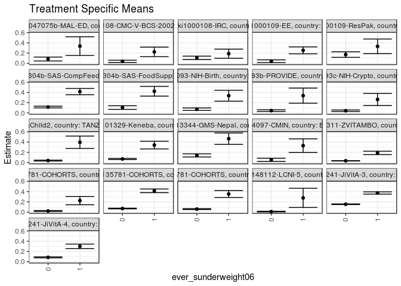

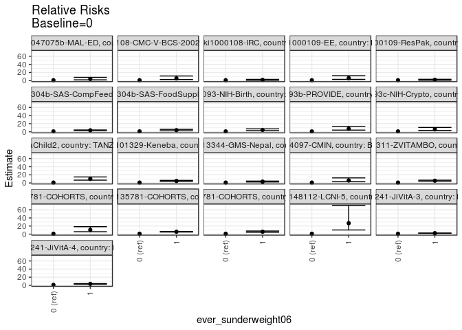

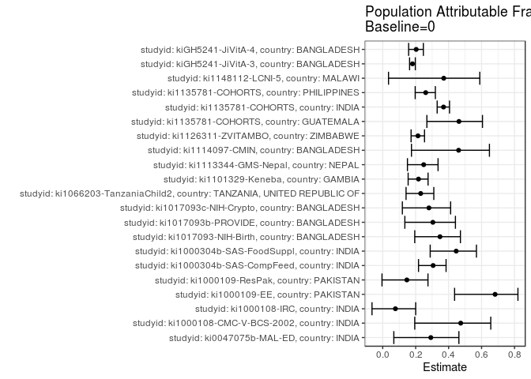

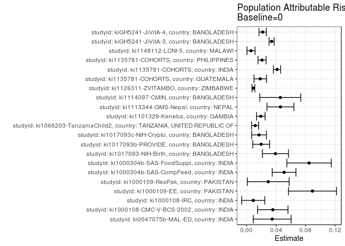

## Results Table

### Parameter: TSM

| studyid | country | intervention_level | baseline_level | estimate | ci_lower | ci_upper |
| --- | --- | --- | --- | --- | --- | --- |
| ki0047075b-MAL-ED | INDIA | 0 | NA | 0.0843774 | 0.0459940 | 0.1227608 |
| ki0047075b-MAL-ED | INDIA | 1 | NA | 0.3360259 | 0.1539426 | 0.5181091 |
| ki1000108-CMC-V-BCS-2002 | INDIA | 0 | NA | 0.0395333 | 0.0171355 | 0.0619311 |
| ki1000108-CMC-V-BCS-2002 | INDIA | 1 | NA | 0.2239795 | 0.1313334 | 0.3166257 |
| ki1000108-IRC | INDIA | 0 | NA | 0.1080583 | 0.0752791 | 0.1408375 |
| ki1000108-IRC | INDIA | 1 | NA | 0.1885957 | 0.0999442 | 0.2772473 |
| ki1000109-EE | PAKISTAN | 0 | NA | 0.0416667 | 0.0149824 | 0.0683509 |
| ki1000109-EE | PAKISTAN | 1 | NA | 0.2531646 | 0.1852731 | 0.3210560 |
| ki1000109-ResPak | PAKISTAN | 0 | NA | 0.1714364 | 0.1175645 | 0.2253084 |
| ki1000109-ResPak | PAKISTAN | 1 | NA | 0.3320435 | 0.1896742 | 0.4744128 |
| ki1000304b-SAS-CompFeed | INDIA | 0 | NA | 0.1154309 | 0.0987201 | 0.1321418 |
| ki1000304b-SAS-CompFeed | INDIA | 1 | NA | 0.4163051 | 0.3557927 | 0.4768174 |
| ki1000304b-SAS-FoodSuppl | INDIA | 0 | NA | 0.1052691 | 0.0698853 | 0.1406528 |
| ki1000304b-SAS-FoodSuppl | INDIA | 1 | NA | 0.4226951 | 0.3277647 | 0.5176256 |
| ki1017093-NIH-Birth | BANGLADESH | 0 | NA | 0.0734343 | 0.0495594 | 0.0973092 |
| ki1017093-NIH-Birth | BANGLADESH | 1 | NA | 0.3362755 | 0.2303107 | 0.4422403 |
| ki1017093b-PROVIDE | BANGLADESH | 0 | NA | 0.0452333 | 0.0281931 | 0.0622735 |
| ki1017093b-PROVIDE | BANGLADESH | 1 | NA | 0.3372597 | 0.1895571 | 0.4849623 |
| ki1017093c-NIH-Crypto | BANGLADESH | 0 | NA | 0.0433699 | 0.0280318 | 0.0587080 |
| ki1017093c-NIH-Crypto | BANGLADESH | 1 | NA | 0.2626611 | 0.1443771 | 0.3809451 |
| ki1066203-TanzaniaChild2 | TANZANIA, UNITED REPUBLIC OF | 0 | NA | 0.0388983 | 0.0303282 | 0.0474685 |
| ki1066203-TanzaniaChild2 | TANZANIA, UNITED REPUBLIC OF | 1 | NA | 0.3947152 | 0.2736770 | 0.5157534 |
| ki1101329-Keneba | GAMBIA | 0 | NA | 0.0695982 | 0.0590959 | 0.0801005 |
| ki1101329-Keneba | GAMBIA | 1 | NA | 0.3402356 | 0.2650005 | 0.4154707 |
| ki1113344-GMS-Nepal | NEPAL | 0 | NA | 0.1388060 | 0.1086384 | 0.1689736 |
| ki1113344-GMS-Nepal | NEPAL | 1 | NA | 0.4646626 | 0.3537638 | 0.5755614 |
| ki1114097-CMIN | BANGLADESH | 0 | NA | 0.0535026 | 0.0224967 | 0.0845086 |
| ki1114097-CMIN | BANGLADESH | 1 | NA | 0.3293149 | 0.1973441 | 0.4612857 |
| ki1126311-ZVITAMBO | ZIMBABWE | 0 | NA | 0.0340156 | 0.0305013 | 0.0375300 |
| ki1126311-ZVITAMBO | ZIMBABWE | 1 | NA | 0.1884415 | 0.1549537 | 0.2219294 |
| ki1135781-COHORTS | GUATEMALA | 0 | NA | 0.0215398 | 0.0121419 | 0.0309378 |
| ki1135781-COHORTS | GUATEMALA | 1 | NA | 0.2249924 | 0.1443988 | 0.3055860 |
| ki1135781-COHORTS | INDIA | 0 | NA | 0.0705297 | 0.0640659 | 0.0769935 |
| ki1135781-COHORTS | INDIA | 1 | NA | 0.4154674 | 0.3796349 | 0.4512998 |
| ki1135781-COHORTS | PHILIPPINES | 0 | NA | 0.0594704 | 0.0504228 | 0.0685180 |
| ki1135781-COHORTS | PHILIPPINES | 1 | NA | 0.3531804 | 0.2847632 | 0.4215976 |
| ki1148112-LCNI-5 | MALAWI | 0 | NA | 0.0102828 | 0.0031722 | 0.0173933 |
| ki1148112-LCNI-5 | MALAWI | 1 | NA | 0.2777778 | 0.0904991 | 0.4650565 |
| kiGH5241-JiVitA-3 | BANGLADESH | 0 | NA | 0.1539694 | 0.1474597 | 0.1604790 |
| kiGH5241-JiVitA-3 | BANGLADESH | 1 | NA | 0.3734414 | 0.3517521 | 0.3951306 |
| kiGH5241-JiVitA-4 | BANGLADESH | 0 | NA | 0.0855396 | 0.0755846 | 0.0954945 |
| kiGH5241-JiVitA-4 | BANGLADESH | 1 | NA | 0.2994760 | 0.2549425 | 0.3440095 |

### Parameter: E(Y)

| studyid | country | intervention_level | baseline_level | estimate | ci_lower | ci_upper |
| --- | --- | --- | --- | --- | --- | --- |
| ki0047075b-MAL-ED | INDIA | NA | NA | 0.1191489 | 0.0776405 | 0.1606574 |
| ki1000108-CMC-V-BCS-2002 | INDIA | NA | NA | 0.0750670 | 0.0482904 | 0.1018437 |
| ki1000108-IRC | INDIA | NA | NA | 0.1170732 | 0.0859146 | 0.1482317 |
| ki1000109-EE | PAKISTAN | NA | NA | 0.1310160 | 0.0967738 | 0.1652583 |
| ki1000109-ResPak | PAKISTAN | NA | NA | 0.2008547 | 0.1494120 | 0.2522974 |
| ki1000304b-SAS-CompFeed | INDIA | NA | NA | 0.1663067 | 0.1478935 | 0.1847199 |
| ki1000304b-SAS-FoodSuppl | INDIA | NA | NA | 0.1900000 | 0.1515071 | 0.2284929 |
| ki1017093-NIH-Birth | BANGLADESH | NA | NA | 0.1125461 | 0.0859151 | 0.1391771 |
| ki1017093b-PROVIDE | BANGLADESH | NA | NA | 0.0650407 | 0.0455353 | 0.0845460 |
| ki1017093c-NIH-Crypto | BANGLADESH | NA | NA | 0.0602740 | 0.0429977 | 0.0775502 |
| ki1066203-TanzaniaChild2 | TANZANIA, UNITED REPUBLIC OF | NA | NA | 0.0505451 | 0.0409848 | 0.0601054 |
| ki1101329-Keneba | GAMBIA | NA | NA | 0.0888980 | 0.0776057 | 0.1001903 |
| ki1113344-GMS-Nepal | NEPAL | NA | NA | 0.1847458 | 0.1534039 | 0.2160876 |
| ki1114097-CMIN | BANGLADESH | NA | NA | 0.0992063 | 0.0622241 | 0.1361886 |
| ki1126311-ZVITAMBO | ZIMBABWE | NA | NA | 0.0432772 | 0.0394419 | 0.0471125 |
| ki1135781-COHORTS | GUATEMALA | NA | NA | 0.0400782 | 0.0280529 | 0.0521035 |
| ki1135781-COHORTS | INDIA | NA | NA | 0.1117877 | 0.1043506 | 0.1192249 |
| ki1135781-COHORTS | PHILIPPINES | NA | NA | 0.0804557 | 0.0703953 | 0.0905161 |
| ki1148112-LCNI-5 | MALAWI | NA | NA | 0.0163317 | 0.0075211 | 0.0251422 |
| kiGH5241-JiVitA-3 | BANGLADESH | NA | NA | 0.1879125 | 0.1813641 | 0.1944608 |
| kiGH5241-JiVitA-4 | BANGLADESH | NA | NA | 0.1073532 | 0.0971813 | 0.1175251 |

### Parameter: RR

| studyid | country | intervention_level | baseline_level | estimate | ci_lower | ci_upper |
| --- | --- | --- | --- | --- | --- | --- |
| ki0047075b-MAL-ED | INDIA | 0 | 0 | 1.000000 | 1.0000000 | 1.000000 |
| ki0047075b-MAL-ED | INDIA | 1 | 0 | 3.982414 | 1.9630584 | 8.079039 |
| ki1000108-CMC-V-BCS-2002 | INDIA | 0 | 0 | 1.000000 | 1.0000000 | 1.000000 |
| ki1000108-CMC-V-BCS-2002 | INDIA | 1 | 0 | 5.665595 | 2.7986664 | 11.469379 |
| ki1000108-IRC | INDIA | 0 | 0 | 1.000000 | 1.0000000 | 1.000000 |
| ki1000108-IRC | INDIA | 1 | 0 | 1.745315 | 0.9962149 | 3.057697 |
| ki1000109-EE | PAKISTAN | 0 | 0 | 1.000000 | 1.0000000 | 1.000000 |
| ki1000109-EE | PAKISTAN | 1 | 0 | 6.075949 | 3.0344654 | 12.165950 |
| ki1000109-ResPak | PAKISTAN | 0 | 0 | 1.000000 | 1.0000000 | 1.000000 |
| ki1000109-ResPak | PAKISTAN | 1 | 0 | 1.936832 | 1.1422467 | 3.284156 |
| ki1000304b-SAS-CompFeed | INDIA | 0 | 0 | 1.000000 | 1.0000000 | 1.000000 |
| ki1000304b-SAS-CompFeed | INDIA | 1 | 0 | 3.606530 | 2.9126881 | 4.465655 |
| ki1000304b-SAS-FoodSuppl | INDIA | 0 | 0 | 1.000000 | 1.0000000 | 1.000000 |
| ki1000304b-SAS-FoodSuppl | INDIA | 1 | 0 | 4.015379 | 2.6801150 | 6.015886 |
| ki1017093-NIH-Birth | BANGLADESH | 0 | 0 | 1.000000 | 1.0000000 | 1.000000 |
| ki1017093-NIH-Birth | BANGLADESH | 1 | 0 | 4.579268 | 2.9085002 | 7.209798 |
| ki1017093b-PROVIDE | BANGLADESH | 0 | 0 | 1.000000 | 1.0000000 | 1.000000 |
| ki1017093b-PROVIDE | BANGLADESH | 1 | 0 | 7.456000 | 4.1788829 | 13.303061 |
| ki1017093c-NIH-Crypto | BANGLADESH | 0 | 0 | 1.000000 | 1.0000000 | 1.000000 |
| ki1017093c-NIH-Crypto | BANGLADESH | 1 | 0 | 6.056294 | 3.4140382 | 10.743494 |
| ki1066203-TanzaniaChild2 | TANZANIA, UNITED REPUBLIC OF | 0 | 0 | 1.000000 | 1.0000000 | 1.000000 |
| ki1066203-TanzaniaChild2 | TANZANIA, UNITED REPUBLIC OF | 1 | 0 | 10.147355 | 6.9550240 | 14.804954 |
| ki1101329-Keneba | GAMBIA | 0 | 0 | 1.000000 | 1.0000000 | 1.000000 |
| ki1101329-Keneba | GAMBIA | 1 | 0 | 4.888570 | 3.7423485 | 6.385862 |
| ki1113344-GMS-Nepal | NEPAL | 0 | 0 | 1.000000 | 1.0000000 | 1.000000 |
| ki1113344-GMS-Nepal | NEPAL | 1 | 0 | 3.347568 | 2.4247576 | 4.621580 |
| ki1114097-CMIN | BANGLADESH | 0 | 0 | 1.000000 | 1.0000000 | 1.000000 |
| ki1114097-CMIN | BANGLADESH | 1 | 0 | 6.155117 | 3.0342064 | 12.486118 |
| ki1126311-ZVITAMBO | ZIMBABWE | 0 | 0 | 1.000000 | 1.0000000 | 1.000000 |
| ki1126311-ZVITAMBO | ZIMBABWE | 1 | 0 | 5.539850 | 4.5115600 | 6.802512 |
| ki1135781-COHORTS | GUATEMALA | 0 | 0 | 1.000000 | 1.0000000 | 1.000000 |
| ki1135781-COHORTS | GUATEMALA | 1 | 0 | 10.445412 | 5.9451310 | 18.352268 |
| ki1135781-COHORTS | INDIA | 0 | 0 | 1.000000 | 1.0000000 | 1.000000 |
| ki1135781-COHORTS | INDIA | 1 | 0 | 5.890670 | 5.1955792 | 6.678754 |
| ki1135781-COHORTS | PHILIPPINES | 0 | 0 | 1.000000 | 1.0000000 | 1.000000 |
| ki1135781-COHORTS | PHILIPPINES | 1 | 0 | 5.938762 | 4.6451431 | 7.592639 |
| ki1148112-LCNI-5 | MALAWI | 0 | 0 | 1.000000 | 1.0000000 | 1.000000 |
| ki1148112-LCNI-5 | MALAWI | 1 | 0 | 27.013889 | 10.2838431 | 70.960844 |
| kiGH5241-JiVitA-3 | BANGLADESH | 0 | 0 | 1.000000 | 1.0000000 | 1.000000 |
| kiGH5241-JiVitA-3 | BANGLADESH | 1 | 0 | 2.425427 | 2.2589147 | 2.604213 |
| kiGH5241-JiVitA-4 | BANGLADESH | 0 | 0 | 1.000000 | 1.0000000 | 1.000000 |
| kiGH5241-JiVitA-4 | BANGLADESH | 1 | 0 | 3.501024 | 2.8934485 | 4.236179 |

### Parameter: PAR

| studyid | country | intervention_level | baseline_level | estimate | ci_lower | ci_upper |
| --- | --- | --- | --- | --- | --- | --- |
| ki0047075b-MAL-ED | INDIA | 0 | NA | 0.0347715 | 0.0091312 | 0.0604118 |
| ki1000108-CMC-V-BCS-2002 | INDIA | 0 | NA | 0.0355337 | 0.0149213 | 0.0561462 |
| ki1000108-IRC | INDIA | 0 | NA | 0.0090149 | -0.0066236 | 0.0246533 |
| ki1000109-EE | PAKISTAN | 0 | NA | 0.0893494 | 0.0567594 | 0.1219393 |
| ki1000109-ResPak | PAKISTAN | 0 | NA | 0.0294183 | 0.0011130 | 0.0577235 |
| ki1000304b-SAS-CompFeed | INDIA | 0 | NA | 0.0508758 | 0.0348179 | 0.0669337 |
| ki1000304b-SAS-FoodSuppl | INDIA | 0 | NA | 0.0847309 | 0.0545761 | 0.1148858 |
| ki1017093-NIH-Birth | BANGLADESH | 0 | NA | 0.0391118 | 0.0214965 | 0.0567271 |
| ki1017093b-PROVIDE | BANGLADESH | 0 | NA | 0.0198073 | 0.0084183 | 0.0311963 |
| ki1017093c-NIH-Crypto | BANGLADESH | 0 | NA | 0.0169040 | 0.0069576 | 0.0268505 |
| ki1066203-TanzaniaChild2 | TANZANIA, UNITED REPUBLIC OF | 0 | NA | 0.0116468 | 0.0069003 | 0.0163932 |
| ki1101329-Keneba | GAMBIA | 0 | NA | 0.0192998 | 0.0134773 | 0.0251223 |
| ki1113344-GMS-Nepal | NEPAL | 0 | NA | 0.0459397 | 0.0276930 | 0.0641865 |
| ki1114097-CMIN | BANGLADESH | 0 | NA | 0.0457037 | 0.0179320 | 0.0734754 |
| ki1126311-ZVITAMBO | ZIMBABWE | 0 | NA | 0.0092616 | 0.0073262 | 0.0111969 |
| ki1135781-COHORTS | GUATEMALA | 0 | NA | 0.0185384 | 0.0099804 | 0.0270964 |
| ki1135781-COHORTS | INDIA | 0 | NA | 0.0412580 | 0.0363772 | 0.0461388 |
| ki1135781-COHORTS | PHILIPPINES | 0 | NA | 0.0209853 | 0.0154882 | 0.0264824 |
| ki1148112-LCNI-5 | MALAWI | 0 | NA | 0.0060489 | 0.0006088 | 0.0114889 |
| kiGH5241-JiVitA-3 | BANGLADESH | 0 | NA | 0.0339431 | 0.0305626 | 0.0373236 |
| kiGH5241-JiVitA-4 | BANGLADESH | 0 | NA | 0.0218137 | 0.0168592 | 0.0267681 |

### Parameter: PAF

| studyid | country | intervention_level | baseline_level | estimate | ci_lower | ci_upper |
| --- | --- | --- | --- | --- | --- | --- |
| ki0047075b-MAL-ED | INDIA | 0 | NA | 0.2918323 | 0.0674308 | 0.4622367 |
| ki1000108-CMC-V-BCS-2002 | INDIA | 0 | NA | 0.4733603 | 0.1943428 | 0.6557476 |
| ki1000108-IRC | INDIA | 0 | NA | 0.0770021 | -0.0651103 | 0.2001531 |
| ki1000109-EE | PAKISTAN | 0 | NA | 0.6819728 | 0.4362210 | 0.8206011 |
| ki1000109-ResPak | PAKISTAN | 0 | NA | 0.1464654 | -0.0043483 | 0.2746327 |
| ki1000304b-SAS-CompFeed | INDIA | 0 | NA | 0.3059154 | 0.2172893 | 0.3845065 |
| ki1000304b-SAS-FoodSuppl | INDIA | 0 | NA | 0.4459524 | 0.2881470 | 0.5687750 |
| ki1017093-NIH-Birth | BANGLADESH | 0 | NA | 0.3475180 | 0.1943637 | 0.4715572 |
| ki1017093b-PROVIDE | BANGLADESH | 0 | NA | 0.3045375 | 0.1343369 | 0.4412744 |
| ki1017093c-NIH-Crypto | BANGLADESH | 0 | NA | 0.2804533 | 0.1191715 | 0.4122041 |
| ki1066203-TanzaniaChild2 | TANZANIA, UNITED REPUBLIC OF | 0 | NA | 0.2304232 | 0.1415959 | 0.3100586 |
| ki1101329-Keneba | GAMBIA | 0 | NA | 0.2171006 | 0.1543288 | 0.2752131 |
| ki1113344-GMS-Nepal | NEPAL | 0 | NA | 0.2486646 | 0.1500684 | 0.3358232 |
| ki1114097-CMIN | BANGLADESH | 0 | NA | 0.4606935 | 0.1744072 | 0.6477059 |
| ki1126311-ZVITAMBO | ZIMBABWE | 0 | NA | 0.2140062 | 0.1721624 | 0.2537350 |
| ki1135781-COHORTS | GUATEMALA | 0 | NA | 0.4625550 | 0.2680513 | 0.6053725 |
| ki1135781-COHORTS | INDIA | 0 | NA | 0.3690745 | 0.3304407 | 0.4054792 |
| ki1135781-COHORTS | PHILIPPINES | 0 | NA | 0.2608307 | 0.1971225 | 0.3194837 |
| ki1148112-LCNI-5 | MALAWI | 0 | NA | 0.3703777 | 0.0352375 | 0.5890965 |
| kiGH5241-JiVitA-3 | BANGLADESH | 0 | NA | 0.1806326 | 0.1630626 | 0.1978337 |
| kiGH5241-JiVitA-4 | BANGLADESH | 0 | NA | 0.2031953 | 0.1573042 | 0.2465873 |